# Bio 607 Mideterm

```r
#Population-Level Effects:
#            Estimate Est.Error l-95% CI u-95% CI
#Intercept   -0.09553   0.21603 -0.51314  0.32800
#Tarsus..mm.  0.37284   0.00663  0.35970  0.38558

fixef(quail_bayes)
```

```
##                Estimate   Est.Error       Q2.5     Q97.5
## Intercept   -0.09852209 0.216529750 -0.5279776 0.3218921
## Tarsus..mm.  0.37292213 0.006661047  0.3597875 0.3859578
```

```r
#              Estimate   Est.Error       Q2.5     Q97.5
#Intercept   -0.1010504 0.219950593 -0.5400430 0.3346686
#Tarsus..mm.  0.3730113 0.006811523  0.3592005 0.3864505
```

5C. For your likelihood fit, are your profiles well behaved? For just the slope, use grid sampling to create a profile. You’ll need to write functions for this, sampling the whole grid of slope and intercept, and then take out the relevant slices as we have done before. Use the results from the fit above to provide the reasonable bounds of what you should be profiling over (3SE should do). Is it well behaved? Plot the profile and give the 80% and 95% CI (remember how we use the chisq here!). Verify your results with profileModel.

```r
library(bbmle)
#creating a likelihood function
norm_likelihood <- function(slope, intercept){

#data generating process. linear regression equation(y = mx + b )
quail_new <- slope*quail_no_na$Tarsus..mm. + intercept

#getting log likelihood, log of product is sum of the logs
sum(dnorm(quail_no_na$Culmen..mm., quail_new, log = TRUE))

}

#creating a grid that's a tibble that includes slope and intercept
quail_grid <- tibble(slope = seq(0.35,0.395, length.out = 100),
                  #intercept and slope sequences are estimations
                     intercept = seq(-0.73,0.54, length.out = 100)) %>%
  group_by(slope, intercept) %>%
  #creating a log likelihood and deviance column
  mutate(log_lik = norm_likelihood(slope, intercept),
         deviance = -2 * log_lik) %>%
  ungroup()

#getting the 80% and 95% confidence intervals
qchisq(0.95, df = 1)/2 #1.920729
```

```
## [1] 1.920729
```

```r
qchisq(0.80, df = 1)/2 # 0.8211872
```

```
## [1] 0.8211872
```

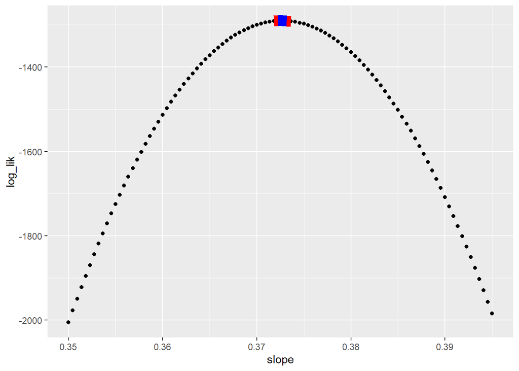

```r
library(ggplot2)

#plot my grid data with slope on the x and log liklihood on the y
ggplot(data=quail_grid,
       mapping=aes(x=slope,
                  y=log_lik)) +
  #adding the 90% confidence interval to the plot
  geom_point() +
  geom_line(data = quail_grid %>% filter(log_lik > (max(log_lik) - 1.92)) %>%
              as.data.frame() %>%
              head(),
            mapping = aes(x = slope, y=log_lik), color = "red", size=5) +
  #adding the 80% confidence interval to the plot
  geom_line(data = quail_grid %>% filter(log_lik >= (max(log_lik) - 0.82)) %>%
          as.data.frame() %>%
              head(),
            mapping = aes(x = slope, y=log_lik), color = "blue", size=5)
```

```r
quail_mle <- glm(Culmen..mm. ~ Tarsus..mm.,
                data = quail_no_na,
                family = gaussian(link = "identity"))

#compare with profileModel
quail_prof_model <- profileModel(quail_mle,
                     objective = "ordinaryDeviance",
                     quantile = qchisq(0.8,0.95))
```

```
## Preliminary iteration .. Done
##
## Profiling for parameter (Intercept) ... Done
## Profiling for parameter Tarsus..mm. ... Done
```

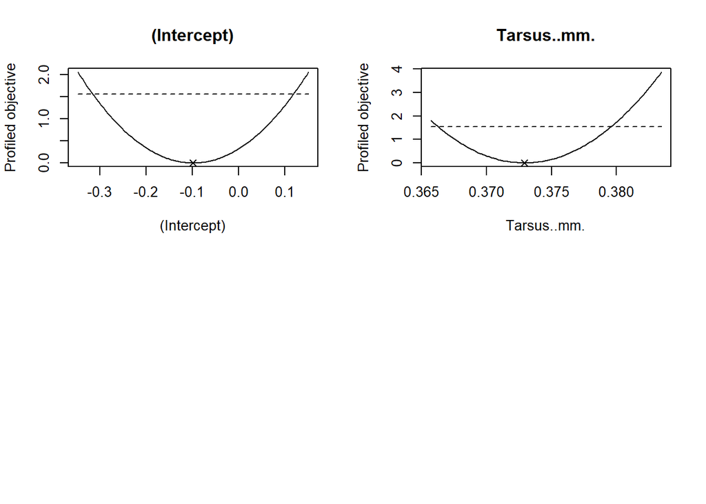

```r
plot(quail_prof_model)
```

```r
#our profile is well behaved. It produced a nice parabola and matches our profile model well. The slope peaks on our graph around .373  which matches the profileModel
```

5D. This data set is pretty big. After excluding NAs in the variables we’re interested in, it’s over 766 lines of data! Now, a lot of data can overwhelm a strong prior. But only to a point. Show first that there is enough data here that a prior for the slope with an estimate of 0.7 and a sd of 0.01 is overwhelmed and produces similar results to the default prior. How different are the results from the original?

Second, randomly sample 10, 100, 300, and 500 data points. At which level is our prior overwhelmed (e.g., the prior slope becomes highly unlikely)? Communicate that visually in the best way you feel gets the point across, and explain your reasoning.